# CIS 8392-Group 6-Final Project-Football Analytics

Ayan Basu, Kumar Shivam, Mitali Warty, Ruchita Thombare

12/08/2021

### Business Context

The primary data for the project has been sourced from [Football API](https://www.football-data.org/documentation/quickstart)

This API gave us privilege of accessing data for 13 competitions in free version of subscription. We also subscribed to its “Odds Add-On” package to pull the teams odds as well to address peer comment given to us. The odds are also being used in the model.

The football data is important as it helps a team’s management to focus on the key areas based on the in-game statistics (player ratings, home wins, away wins) to drive towards a favorable outcome for the team.

### Problem Description

Football is the world’s most popular ball game in terms of participants and spectators. It is played by 250 million players in over 200 countries. Owing to its magnitude, the outcome of a football match is of a significant impact to the team owners, management, and of course, the betters. Sports betting is a $500 billion market according to Sydney Herald.

Off late, it has been associated with important monetary transactions and financial sponsoring. People and organizations have turned towards investing in the football clubs and leagues and therefore, the outcome of a match not only affects the team management but also numerous other people associated wiht it. Predicting an outcome of a football match hence drives the market on the whole.

Through this project, we’ll be using in-game statistics which would help us evaluate a team’s performance instead of just leveraging the actual number of “goals scored” metric from prior matches. We would combine some key metrics of a team like their half time scores, team’s overall offensive and defensive ratings which are updated after each game to build model predicting the outcome of future matches.

### URL of the collected data from API and other data

[Link to the data](https://github.com/AyanB15/Big-Data-Anaytics--R/blob/main/Data.rar)

### Data summary, Cleaning, Wrangling, Exploration, and Discussion

The primary source of data is from the Football API: https://www.football-data.org/documentation/quickstart. The data consists of the competition names, matches played in those competitions, team names, and data (including live results, lineups/subs, goalscorers, bookings, squads).

##### Initializing and Exporting the libraries

```r
knitr::opts_chunk$set()
rm(list = ls())
library(ggplot2)
library(caret)
library(httr)
library(tibble)
library(tidyverse)
library(magrittr)
library(purrr)
library(repurrrsive)
library(rlist)
library(glue)
library(patchwork)
library(data.table)
library(kableExtra)
library(h2o)
library(skimr)
library(recipes)
library(stringr)
library(tracerer)
library(ggthemes)
```

##### Retrieve the data from the football API

##### Call to the API

```r
token = "30f473d0cf614b5b82c6e13f9f7df5ad"
football_api = GET("https://api.football-data.org//v2/competitions",
                       add_headers("X-Auth-Token"= token)
)
api_content = content(football_api)
competitions = api_content$competitions
```

Below is the list of some of the competitions whose data is availale to us.

```r
id_vector = map_int(competitions, ~.$id)
name_vector = map_chr(competitions, ~.$name)

all_competitions = data.frame(
  id = id_vector,
  name = name_vector
)

kable(head(all_competitions,10),format="html",table.attr="style='width:30%;'") %>%
  kableExtra::kable_styling() %>%
  kable_classic(full_width = F,font_size=14)
```

| id | name |
| --- | --- |
| 2006 | WC Qualification CAF |
| 2023 | Primera B Nacional |
| 2024 | Liga Profesional |
| 2025 | Supercopa Argentina |
| 2149 | Copa Liga Profesional |
| 2147 | WC Qualification AFC |
| 2008 | A League |
| 2026 | FFA Cup |
| 2020 | Erste Liga |
| 2012 | Bundesliga |

The free version of API only allows us to have below list of 13 competition ID’s.

```r
avail_competition_id = c("2000", "2001", "2002", "2003", "2013", "2014", "2015", "2016", "2017", "2018", "2019", "2021","2152")

# Available competitions
avail_competitions = all_competitions %>%
  filter(all_competitions$id %in% avail_competition_id)

kable(avail_competitions,format="html",table.attr="style='width:30%;'") %>%
  kableExtra::kable_styling() %>%
  kable_classic(full_width = F,font_size=14)
```

| id | name |
| --- | --- |
| 2013 | Campeonato Brasileiro Série A |
| 2016 | Championship |
| 2021 | Premier League |
| 2001 | UEFA Champions League |
| 2018 | European Championship |
| 2015 | Ligue 1 |
| 2002 | Bundesliga |
| 2019 | Serie A |
| 2003 | Eredivisie |
| 2017 | Primeira Liga |
| 2152 | Copa Libertadores |
| 2014 | Primera Division |
| 2000 | FIFA World Cup |

Once we know the competitions, we can now pull the match details.

```r
#Retrieving all match details from the API corresponding to the list of available competitions
match_content = list()

for(id in avail_competitions$id){
  url = glue("http://api.football-data.org/v2/competitions/{id}/matches?dateFrom=2021-05-30&dateTo=2021-12-01")
  matches_comp = GET(url, add_headers("X-Auth-Token"= token))
  match_content = append(match_content, content(matches_comp))
}

all_matches = match_content[names(match_content) == "matches"]
```

The data retrieved from the API is in the form of a list. We need to unnest it and convert it into a dataframe.

```r
matches_df = data.frame()

for(x in 1:11){
  tbl <- as_tibble(all_matches[x])
  matches_df <- bind_rows(matches_df, unnest_wider(tbl,matches))
}

kable(head(matches_df,10),format="html",table.attr="style='width:30%;'") %>%
  kableExtra::kable_styling() %>%
  kable_classic(full_width = F,font_size=14)
```

| id | season | utcDate | status | matchday | stage | lastUpdated | odds | score | homeTeam | awayTeam | referees | group |
| --- | --- | --- | --- | --- | --- | --- | --- | --- | --- | --- | --- | --- |
| 324726 | 726 , 2021-05-30, 2021-12-05, 37 | 2021-05-30T00:00:00Z | FINISHED | 1 | REGULAR_SEASON | 2021-12-08T16:20:12Z | 1.80, 3.51, 4.34 | DRAW , REGULAR, 0 , 0 , 0 , 0 | 1776 , São Paulo FC | 1765 , Fluminense FC | NULL | NA |
| 325069 | 726 , 2021-05-30, 2021-12-05, 37 | 2021-05-30T14:00:00Z | FINISHED | 1 | REGULAR_SEASON | 2021-12-08T16:20:12Z | 1.34, 5.07, 7.96 | AWAY_TEAM, REGULAR , 1 , 2 , 1 , 0 | 1766 , CA Mineiro | 3984 , Fortaleza EC | NULL | NA |
| 325071 | 726 , 2021-05-30, 2021-12-05, 37 | 2021-05-30T19:00:00Z | FINISHED | 1 | REGULAR_SEASON | 2021-12-08T16:20:12Z | 3.09, 3.02, 2.40 | HOME_TEAM, REGULAR , 3 , 2 , 2 , 1 | 1837 , Ceará SC | 1767 , Grêmio FBPA | NULL | NA |
| 325076 | 726 , 2021-05-30, 2021-12-05, 37 | 2021-05-30T19:00:00Z | FINISHED | 1 | REGULAR_SEASON | 2021-12-08T16:20:12Z | 1.66, 3.74, 4.91 | HOME_TEAM, REGULAR , 1 , 0 , 0 , 0 | 1783 , CR Flamengo | 1769 , SE Palmeiras | NULL | NA |
| 325068 | 726 , 2021-05-30, 2021-12-05, 37 | 2021-05-30T21:15:00Z | FINISHED | 1 | REGULAR_SEASON | 2021-12-08T16:20:12Z | 1.86, 3.47, 4.10 | AWAY_TEAM, REGULAR , 0 , 1 , 0 , 1 | 1779 , SC Corinthians Paulista | 3988 , AC Goianiense | NULL | NA |
| 325073 | 726 , 2021-05-30, 2021-12-05, 37 | 2021-05-30T21:15:00Z | FINISHED | 1 | REGULAR_SEASON | 2021-12-08T16:20:12Z | 2.08, 3.35, 3.40 | HOME_TEAM, REGULAR , 1 , 0 , 0 , 0 | 1768 , CA Paranaense | 1838 , América FC | NULL | NA |
| 325074 | 726 , 2021-05-30, 2021-12-05, 37 | 2021-05-30T21:15:00Z | FINISHED | 1 | REGULAR_SEASON | 2021-12-08T16:20:12Z | 3.19, 3.24, 2.22 | AWAY_TEAM, REGULAR , 0 , 3 , 0 , 2 | 1772 , Chapecoense AF | 4286 , RB Bragantino | NULL | NA |
| 325070 | 726 , 2021-05-30, 2021-12-05, 37 | 2021-05-30T23:30:00Z | FINISHED | 1 | REGULAR_SEASON | 2021-12-08T16:20:12Z | 1.36, 4.80, 7.98 | DRAW , REGULAR, 2 , 2 , 2 , 0 | 6684 , SC Internacional | 1778 , SC Recife | NULL | NA |
| 325065 | 726 , 2021-05-30, 2021-12-05, 37 | 2021-06-05T22:00:00Z | FINISHED | 2 | REGULAR_SEASON | 2021-12-08T16:20:12Z | 3.69, 3.11, 2.08 | HOME_TEAM, REGULAR , 2 , 0 , 1 , 0 | 3988 , AC Goianiense | 1776 , São Paulo FC | NULL | NA |
| 325059 | 726 , 2021-05-30, 2021-12-05, 37 | 2021-06-06T00:00:00Z | FINISHED | 2 | REGULAR_SEASON | 2021-12-08T16:20:12Z | 1.93, 3.35, 3.93 | HOME_TEAM, REGULAR , 3 , 1 , 1 , 1 | 6685 , Santos FC | 1837 , Ceará SC | NULL | NA |

```r
matches_df <- subset (matches_df, select = -c(id, season, referees, group))
```

##### Data cleaning, wrangling and tidying

Un-nesting list data for odds column:

```r
matches_df  <- matches_df %>%
  mutate(df = map(odds, ~ .x %>%
                    map_df(magrittr::extract,)))

matches_df  <- matches_df  %>%
  select(-odds) %>%
  unnest(df)

#Renaming the columns for enhance understanding
matches_df <- matches_df %>%
  dplyr::rename(
    Odds.homeWin = homeWin,
    Odds.draw = draw,
    Odds.awayWin = awayWin
  )
```

Un-nesting list data for homeTeam column

```r
matches_df  <- matches_df %>%
  mutate(df = map(homeTeam, ~ .x %>%
                    map_df(magrittr::extract,
                  )))

matches_df  <- matches_df  %>%
  select(-homeTeam) %>%
  unnest(df)

matches_df <- subset (matches_df, select = -c(id))
matches_df <- matches_df %>%
  dplyr::rename(
    homeTeam = name
  )
```

Un-nesting list data for awayTeam column

```r
matches_df  <- matches_df %>%
  mutate(df = map(awayTeam, ~ .x %>%
                    map_df(magrittr::extract,
                  )))
matches_df  <- matches_df  %>%
  select(-awayTeam) %>%
  unnest(df)

matches_df <- subset (matches_df, select = -c(id))

matches_df <- matches_df %>%
  dplyr::rename(
    awayTeam = name
  )
```

Un-nesting list data for scores column. This will yield full time and half time goals of the homeTeam and awayTeam

```r
scores = matches_df$score
winner_vector = map_chr(scores,"winner", .default = NA)

fullTimeScores = map(scores,"fullTime")
fTHome = map_int(fullTimeScores,"homeTeam", .default = NA)
fTAway = map_int(fullTimeScores,"awayTeam", .default = NA)

halfTimeScores = map(scores,"halfTime")
hTHome = map_int(halfTimeScores,"homeTeam", .default = NA)
hTAway = map_int(fullTimeScores,"awayTeam", .default = NA)

matches_df$winner = winner_vector
matches_df$fTHome = fTHome
matches_df$fTAway = fTAway
matches_df$hTHome = hTHome
matches_df$hTAway = hTAway

football_df <- subset (matches_df, select = -c(score))
football_df <- football_df[, c("Odds.homeWin","Odds.draw","Odds.awayWin","hTHome", "hTAway","fTHome", "fTAway", "homeTeam", "awayTeam","winner")]

kable(head(football_df,20),format="html",table.attr="style='width:30%;'") %>%
  kableExtra::kable_styling() %>%
  kable_classic(full_width = F,font_size=14)
```

| Odds.homeWin | Odds.draw | Odds.awayWin | hTHome | hTAway | fTHome | fTAway | homeTeam | awayTeam | winner |
| --- | --- | --- | --- | --- | --- | --- | --- | --- | --- |
| 1.80 | 3.51 | 4.34 | 0 | 0 | 0 | 0 | São Paulo FC | Fluminense FC | DRAW |
| 1.34 | 5.07 | 7.96 | 1 | 2 | 1 | 2 | CA Mineiro | Fortaleza EC | AWAY_TEAM |
| 3.09 | 3.02 | 2.40 | 2 | 2 | 3 | 2 | Ceará SC | Grêmio FBPA | HOME_TEAM |
| 1.66 | 3.74 | 4.91 | 0 | 0 | 1 | 0 | CR Flamengo | SE Palmeiras | HOME_TEAM |
| 1.86 | 3.47 | 4.10 | 0 | 1 | 0 | 1 | SC Corinthians Paulista | AC Goianiense | AWAY_TEAM |
| 2.08 | 3.35 | 3.40 | 0 | 0 | 1 | 0 | CA Paranaense | América FC | HOME_TEAM |
| 3.19 | 3.24 | 2.22 | 0 | 3 | 0 | 3 | Chapecoense AF | RB Bragantino | AWAY_TEAM |
| 1.36 | 4.80 | 7.98 | 2 | 2 | 2 | 2 | SC Internacional | SC Recife | DRAW |
| 3.69 | 3.11 | 2.08 | 1 | 0 | 2 | 0 | AC Goianiense | São Paulo FC | HOME_TEAM |
| 1.93 | 3.35 | 3.93 | 1 | 1 | 3 | 1 | Santos FC | Ceará SC | HOME_TEAM |
| 1.85 | 3.31 | 4.35 | 1 | 3 | 3 | 3 | RB Bragantino | EC Bahia | DRAW |
| 1.43 | 4.23 | 7.33 | 1 | 0 | 1 | 0 | Fluminense FC | Cuiabá EC | HOME_TEAM |
| 2.74 | 3.08 | 2.61 | 0 | 1 | 0 | 1 | América FC | SC Corinthians Paulista | AWAY_TEAM |
| 3.23 | 2.91 | 2.39 | 2 | 1 | 5 | 1 | Fortaleza EC | SC Internacional | HOME_TEAM |
| 2.93 | 3.22 | 2.36 | 0 | 3 | 0 | 3 | EC Juventude | CA Paranaense | AWAY_TEAM |
| 1.29 | 5.30 | 9.37 | 3 | 1 | 3 | 1 | SE Palmeiras | Chapecoense AF | HOME_TEAM |
| 5.27 | 3.57 | 1.66 | 0 | 1 | 0 | 1 | SC Recife | CA Mineiro | AWAY_TEAM |
| 1.50 | 4.20 | 6.27 | 0 | 0 | 0 | 0 | Santos FC | EC Juventude | DRAW |
| 1.83 | 3.45 | 4.29 | 1 | 1 | 1 | 1 | SE Palmeiras | SC Corinthians Paulista | DRAW |
| 2.32 | 3.16 | 3.10 | 1 | 0 | 1 | 0 | CA Mineiro | São Paulo FC | HOME_TEAM |

##### Secondary Data

We are using secondary data to enrich the existing primary data retrieved from the API.

```r
for (j in c('/SP1','/SP2','/E0')){
  url <- c('http://football-data.co.uk/mmz4281/',paste(c(j,'.csv'), collapse=""))
  for(i in 0:18){
    if (i < 9){
      season_start <- paste(c('0',i), collapse="")
      season_end <- paste(c('0',i+1), collapse="")
    }
    else {
      if (i == 9){
        season_start <- paste(c('0',i), collapse="")
        season_end <- i+1
      }
      else {
        season_start <- i
        season_end <- i+1
      }
    }
    sec_df <- read.csv(file = paste(url, collapse=paste(c(season_start,season_end), collapse="")))
    sec_df <- sec_df[, c("IWH", "IWD", "IWA","HTHG","HTAG","FTHG","FTAG","HomeTeam","AwayTeam","FTR")]

    setnames(sec_df, old = names(sec_df),
             new = c("Odds.homeWin","Odds.draw","Odds.awayWin","hTHome", "hTAway","fTHome","fTAway","homeTeam", "awayTeam","winner"))


    sec_df$winner <- as.character(sec_df$winner)
    sec_df$winner <- ifelse(sec_df$winner == "H","HOME_TEAM",sec_df$winner)
    sec_df$winner <- ifelse(sec_df$winner == "A","AWAY_TEAM",sec_df$winner)
    sec_df$winner <- ifelse(sec_df$winner == "D","DRAW",sec_df$winner)

    football_df <- rbind(football_df, sec_df)
  }
}

kable(head(football_df,20),format="html",table.attr="style='width:30%;'") %>%
  kableExtra::kable_styling() %>%
  kable_classic(full_width = F,font_size=14)
```

| Odds.homeWin | Odds.draw | Odds.awayWin | hTHome | hTAway | fTHome | fTAway | homeTeam | awayTeam | winner |
| --- | --- | --- | --- | --- | --- | --- | --- | --- | --- |
| 1.80 | 3.51 | 4.34 | 0 | 0 | 0 | 0 | São Paulo FC | Fluminense FC | DRAW |
| 1.34 | 5.07 | 7.96 | 1 | 2 | 1 | 2 | CA Mineiro | Fortaleza EC | AWAY_TEAM |
| 3.09 | 3.02 | 2.40 | 2 | 2 | 3 | 2 | Ceará SC | Grêmio FBPA | HOME_TEAM |
| 1.66 | 3.74 | 4.91 | 0 | 0 | 1 | 0 | CR Flamengo | SE Palmeiras | HOME_TEAM |
| 1.86 | 3.47 | 4.10 | 0 | 1 | 0 | 1 | SC Corinthians Paulista | AC Goianiense | AWAY_TEAM |
| 2.08 | 3.35 | 3.40 | 0 | 0 | 1 | 0 | CA Paranaense | América FC | HOME_TEAM |
| 3.19 | 3.24 | 2.22 | 0 | 3 | 0 | 3 | Chapecoense AF | RB Bragantino | AWAY_TEAM |
| 1.36 | 4.80 | 7.98 | 2 | 2 | 2 | 2 | SC Internacional | SC Recife | DRAW |
| 3.69 | 3.11 | 2.08 | 1 | 0 | 2 | 0 | AC Goianiense | São Paulo FC | HOME_TEAM |
| 1.93 | 3.35 | 3.93 | 1 | 1 | 3 | 1 | Santos FC | Ceará SC | HOME_TEAM |
| 1.85 | 3.31 | 4.35 | 1 | 3 | 3 | 3 | RB Bragantino | EC Bahia | DRAW |
| 1.43 | 4.23 | 7.33 | 1 | 0 | 1 | 0 | Fluminense FC | Cuiabá EC | HOME_TEAM |
| 2.74 | 3.08 | 2.61 | 0 | 1 | 0 | 1 | América FC | SC Corinthians Paulista | AWAY_TEAM |
| 3.23 | 2.91 | 2.39 | 2 | 1 | 5 | 1 | Fortaleza EC | SC Internacional | HOME_TEAM |
| 2.93 | 3.22 | 2.36 | 0 | 3 | 0 | 3 | EC Juventude | CA Paranaense | AWAY_TEAM |
| 1.29 | 5.30 | 9.37 | 3 | 1 | 3 | 1 | SE Palmeiras | Chapecoense AF | HOME_TEAM |
| 5.27 | 3.57 | 1.66 | 0 | 1 | 0 | 1 | SC Recife | CA Mineiro | AWAY_TEAM |
| 1.50 | 4.20 | 6.27 | 0 | 0 | 0 | 0 | Santos FC | EC Juventude | DRAW |
| 1.83 | 3.45 | 4.29 | 1 | 1 | 1 | 1 | SE Palmeiras | SC Corinthians Paulista | DRAW |
| 2.32 | 3.16 | 3.10 | 1 | 0 | 1 | 0 | CA Mineiro | São Paulo FC | HOME_TEAM |

Check and remove any NULL values from the data.

```r
#Check for any NULL values
colSums(is.na(football_df))
```

```
## Odds.homeWin    Odds.draw Odds.awayWin       hTHome       hTAway       fTHome
##          887          887          891          597          596          574
##       fTAway     homeTeam     awayTeam       winner
##          574            0            0            1
```

```r
#Drop null valuess
football_df <- drop_na(football_df)
```

The secondary data and the API data had team names written in different way, so renaming the team names is important to remove any inconsistency.

```r
football_df$homeTeam <- gsub('1. FC', 'dummy', football_df$homeTeam)
football_df$awayTeam <- gsub('1. FC', 'dummy', football_df$awayTeam)
football_df$homeTeam <- gsub(' FC', '', football_df$homeTeam)
football_df$awayTeam <- gsub(' FC', '', football_df$awayTeam)
football_df$homeTeam <- gsub(' CF', '', football_df$homeTeam)
football_df$awayTeam <- gsub(' CF', '', football_df$awayTeam)
football_df$homeTeam <- gsub('dummy', '1. FC', football_df$homeTeam)
football_df$awayTeam <- gsub('dummy', '1. FC', football_df$awayTeam)
football_df$homeTeam <- gsub(' AFC', '', football_df$homeTeam)
football_df$awayTeam <- gsub(' AFC', '', football_df$awayTeam)
football_df$homeTeam <- gsub('Barcelona', 'FC Barcelona', football_df$homeTeam)
football_df$awayTeam <- gsub('Barcelona', 'FC Barcelona', football_df$awayTeam)
football_df$homeTeam <- gsub('Bournemouth', 'AFC Bournemouth', football_df$homeTeam)
football_df$awayTeam <- gsub('Bournemouth', 'AFC Bournemouth', football_df$awayTeam)
football_df$homeTeam <- gsub('Brighton', 'Brighton & Hove Albion', football_df$homeTeam)
football_df$awayTeam <- gsub('Brighton', 'Brighton & Hove Albion', football_df$awayTeam)
football_df$homeTeam <- gsub('Club Atl?tico de Madrid', 'Ath Madrid', football_df$homeTeam)
football_df$awayTeam <- gsub('Club Atl?tico de Madrid', 'Ath Madrid', football_df$awayTeam)
football_df$homeTeam <- gsub('Coventry', 'Coventry City', football_df$homeTeam)
football_df$awayTeam <- gsub('Coventry', 'Coventry City', football_df$awayTeam)
football_df$homeTeam <- gsub('Eibar', 'SD Eibar', football_df$homeTeam)
football_df$awayTeam <- gsub('Eibar', 'SD Eibar', football_df$awayTeam)
football_df$homeTeam <- gsub('Huddersfield', 'Huddersfield Town', football_df$homeTeam)
football_df$awayTeam <- gsub('Huddersfield', 'Huddersfield Town', football_df$awayTeam)
football_df$homeTeam <- gsub('Leeds', 'Leeds United', football_df$homeTeam)
football_df$awayTeam <- gsub('Leeds', 'Leeds United', football_df$awayTeam)
football_df$homeTeam <- gsub('Levante', 'Levante UD', football_df$homeTeam)
football_df$awayTeam <- gsub('Levante', 'Levante UD', football_df$awayTeam)
football_df$homeTeam <- gsub('Man City', 'Manchester City', football_df$homeTeam)
football_df$awayTeam <- gsub('Man City', 'Manchester City', football_df$awayTeam)
football_df$homeTeam <- gsub('Man United', 'Manchester United', football_df$homeTeam)
football_df$awayTeam <- gsub('Man United', 'Manchester United', football_df$awayTeam)
football_df$homeTeam <- gsub('Newcastle', 'Newcastle United', football_df$homeTeam)
football_df$awayTeam <- gsub('Newcastle', 'Newcastle United', football_df$awayTeam)
football_df$homeTeam <- gsub('Norwich', 'Norwich City', football_df$homeTeam)
football_df$awayTeam <- gsub('Norwich', 'Norwich City', football_df$awayTeam)
football_df$homeTeam <- gsub('Osasuna', 'CA Osasuna', football_df$homeTeam)
football_df$awayTeam <- gsub('Osasuna', 'CA Osasuna', football_df$awayTeam)
football_df$homeTeam <- gsub('Real Sociedad de F?tbol', 'Real Sociedad', football_df$homeTeam)
football_df$awayTeam <- gsub('Real Sociedad de F?tbol', 'Real Sociedad', football_df$awayTeam)
football_df$homeTeam <- gsub('Sociedad', 'Real Sociedad', football_df$homeTeam)
football_df$awayTeam <- gsub('Sociedad', 'Real Sociedad', football_df$awayTeam)
football_df$homeTeam <- gsub('Tottenham', 'Tottenham Hotspur', football_df$homeTeam)
football_df$awayTeam <- gsub('Tottenham', 'Tottenham Hotspur', football_df$awayTeam)
football_df$homeTeam <- gsub('West Brom', 'West Bromwich Albion', football_df$homeTeam)
football_df$awayTeam <- gsub('West Brom', 'West Bromwich Albion', football_df$awayTeam)
football_df$homeTeam <- gsub('West Ham', 'West Ham United', football_df$homeTeam)
football_df$awayTeam <- gsub('West Ham', 'West Ham United', football_df$awayTeam)
football_df$homeTeam <- gsub('Wolves', 'Wolverhampton Wanderers', football_df$homeTeam)
football_df$awayTeam <- gsub('Wolves', 'Wolverhampton Wanderers', football_df$awayTeam)
```

The dataset has 24458 rows:

```r
nrow(football_df)
```

```
## [1] 24458
```

Some records in the dataframe is displayed below:

```r
kable(head(football_df,20),format="html",table.attr="style='width:30%;'") %>%
  kableExtra::kable_styling() %>%
  kable_classic(full_width = F,font_size=14)
```

| Odds.homeWin | Odds.draw | Odds.awayWin | hTHome | hTAway | fTHome | fTAway | homeTeam | awayTeam | winner |
| --- | --- | --- | --- | --- | --- | --- | --- | --- | --- |
| 1.80 | 3.51 | 4.34 | 0 | 0 | 0 | 0 | São Paulo | Fluminense | DRAW |
| 1.34 | 5.07 | 7.96 | 1 | 2 | 1 | 2 | CA Mineiro | Fortaleza EC | AWAY_TEAM |
| 3.09 | 3.02 | 2.40 | 2 | 2 | 3 | 2 | Ceará SC | Grêmio FBPA | HOME_TEAM |
| 1.66 | 3.74 | 4.91 | 0 | 0 | 1 | 0 | CR Flamengo | SE Palmeiras | HOME_TEAM |
| 1.86 | 3.47 | 4.10 | 0 | 1 | 0 | 1 | SC Corinthians Paulista | AC Goianiense | AWAY_TEAM |
| 2.08 | 3.35 | 3.40 | 0 | 0 | 1 | 0 | CA Paranaense | América | HOME_TEAM |
| 3.19 | 3.24 | 2.22 | 0 | 3 | 0 | 3 | Chapecoense AF | RB Bragantino | AWAY_TEAM |
| 1.36 | 4.80 | 7.98 | 2 | 2 | 2 | 2 | SC Internacional | SC Recife | DRAW |
| 3.69 | 3.11 | 2.08 | 1 | 0 | 2 | 0 | AC Goianiense | São Paulo | HOME_TEAM |
| 1.93 | 3.35 | 3.93 | 1 | 1 | 3 | 1 | Santos | Ceará SC | HOME_TEAM |
| 1.85 | 3.31 | 4.35 | 1 | 3 | 3 | 3 | RB Bragantino | EC Bahia | DRAW |
| 1.43 | 4.23 | 7.33 | 1 | 0 | 1 | 0 | Fluminense | Cuiabá EC | HOME_TEAM |
| 2.74 | 3.08 | 2.61 | 0 | 1 | 0 | 1 | América | SC Corinthians Paulista | AWAY_TEAM |
| 3.23 | 2.91 | 2.39 | 2 | 1 | 5 | 1 | Fortaleza EC | SC Internacional | HOME_TEAM |
| 2.93 | 3.22 | 2.36 | 0 | 3 | 0 | 3 | EC Juventude | CA Paranaense | AWAY_TEAM |
| 1.29 | 5.30 | 9.37 | 3 | 1 | 3 | 1 | SE Palmeiras | Chapecoense AF | HOME_TEAM |
| 5.27 | 3.57 | 1.66 | 0 | 1 | 0 | 1 | SC Recife | CA Mineiro | AWAY_TEAM |
| 1.50 | 4.20 | 6.27 | 0 | 0 | 0 | 0 | Santos | EC Juventude | DRAW |
| 1.83 | 3.45 | 4.29 | 1 | 1 | 1 | 1 | SE Palmeiras | SC Corinthians Paulista | DRAW |
| 2.32 | 3.16 | 3.10 | 1 | 0 | 1 | 0 | CA Mineiro | São Paulo | HOME_TEAM |

##### Ratings Data to enrich the existing data

We’re also using secondary data in the form of ratings of teams. This will also be used for modeling.

```r
ratings_df <- read.csv(file = "https://raw.githubusercontent.com/AyanB15/Big-Data-Anaytics--R/main/SoccerClubRatings.csv")

#Check for any NULL values
colSums(is.na(ratings_df))
```

```
##  Teams League    ATT    MID    DEF    OVR
##      0      0     55     55     55     55
```

```r
#Drop null values
ratings_df <- drop_na(ratings_df)

kable(head(ratings_df,20),format="html",table.attr="style='width:30%;'") %>%
  kableExtra::kable_styling() %>%
  kable_classic(full_width = F,font_size=14)
```

| Teams | League | ATT | MID | DEF | OVR |
| --- | --- | --- | --- | --- | --- |
| Liverpool | Premier League | 86 | 83 | 79 | 85 |
| Manchester City | Premier League | 85 | 86 | 83 | 85 |
| Real Madrid | LaLiga Santander | 84 | 86 | 84 | 85 |
| FC Bayern München | Bundesliga | 92 | 85 | 81 | 84 |
| FC Barcelona | LaLiga Santander | 87 | 83 | 81 | 84 |
| Paris Saint-Germain | Ligue 1 Uber Eats | 85 | 83 | 82 | 84 |
| Juventus | Serie A TIM | 87 | 81 | 83 | 83 |
| Ath Madrid | LaLiga Santander | 84 | 82 | 83 | 83 |
| Tottenham Hotspur | Premier League | 89 | 82 | 81 | 82 |
| Manchester United | Premier League | 83 | 82 | 82 | 82 |
| Inter | Serie A TIM | 83 | 81 | 83 | 82 |
| Chelsea | Premier League | 82 | 84 | 81 | 82 |
| Borussia Dortmund | Bundesliga | 85 | 80 | 80 | 81 |
| Sevilla FC | LaLiga Santander | 80 | 81 | 82 | 81 |
| Lazio | Serie A TIM | 82 | 81 | 78 | 80 |
| Napoli | Serie A TIM | 82 | 80 | 80 | 80 |
| Villarreal CF | LaLiga Santander | 82 | 79 | 79 | 80 |
| Arsenal | Premier League | 82 | 79 | 79 | 80 |
| Leicester City | Premier League | 80 | 81 | 79 | 80 |
| RB Leipzig | Bundesliga | 79 | 80 | 80 | 80 |

Removing some unnecessary columns from the ratings file.

```r
ratings_df <- select(ratings_df,-c('ATT','MID','DEF','League'))
names(ratings_df)[names(ratings_df) == "ï..Name"] <- "Teams"
ratings_df$Teams <- as.character(ratings_df$Teams)
ratings_df$Teams <- gsub('1. FC', 'dummy', ratings_df$Teams)
ratings_df$Teams <- gsub('dummy', '1. FC', ratings_df$Teams)

ratings_df$Teams <- gsub(' FC', '', ratings_df$Teams)
ratings_df$Teams <- gsub(' AFC', '', ratings_df$Teams)
ratings_df$Teams <- gsub(' CF', '', ratings_df$Teams)

ratings_df$OVR <- ratings_df$OVR/100
```

Now, we have 2 datasets: first one from the API and secondary data and the second one is the ratings dataset. Both the datasets needs to be merged using joins to find out the corresponding team ratings from the ratings file.

```r
setnames(ratings_df, old = c("Teams","OVR"),
         new = c("homeTeam","homePerformancerating"))

football_df2 <- inner_join(football_df, ratings_df)

setnames(ratings_df, old = c("homeTeam","homePerformancerating"),
         new = c("awayTeam","awayPerformancerating"))

football_df2 <- inner_join(football_df2, ratings_df)

# Assessing the winner based on the outcome of the match
#0: means match ended in a Draw
#1: Home team Won
#2: Away team Won
football_df2$winner <- ifelse(football_df2$winner == "DRAW",0,football_df2$winner)
football_df2$winner <- ifelse(football_df2$winner == "HOME_TEAM",1,football_df2$winner)
football_df2$winner <- ifelse(football_df2$winner == "AWAY_TEAM",2,football_df2$winner)
football_df2$winner <- as.factor(football_df2$winner)
```

The final dataset after data cleaning, wrangling and tidying.

```r
kable(head(football_df2,20),format="html",table.attr="style='width:30%;'") %>%
  kableExtra::kable_styling() %>%
  kable_classic(full_width = F,font_size=14)
```

| Odds.homeWin | Odds.draw | Odds.awayWin | hTHome | hTAway | fTHome | fTAway | homeTeam | awayTeam | winner | homePerformancerating | awayPerformancerating |
| --- | --- | --- | --- | --- | --- | --- | --- | --- | --- | --- | --- |
| 1.80 | 3.51 | 4.34 | 0 | 0 | 0 | 0 | São Paulo | Fluminense | 0 | 0.75 | 0.72 |
| 2.09 | 3.20 | 3.59 | 0 | 0 | 1 | 0 | Fluminense | Santos | 1 | 0.72 | 0.73 |
| 2.77 | 3.25 | 2.47 | 2 | 0 | 2 | 0 | Santos | São Paulo | 1 | 0.73 | 0.75 |
| 2.63 | 3.01 | 2.77 | 0 | 1 | 2 | 1 | Fluminense | São Paulo | 1 | 0.72 | 0.75 |
| 2.61 | 3.08 | 2.78 | 1 | 0 | 2 | 0 | Santos | Fluminense | 1 | 0.73 | 0.72 |
| 2.40 | 3.18 | 3.00 | 0 | 1 | 1 | 1 | Cardiff City | Barnsley | 0 | 0.71 | 0.68 |
| 2.39 | 3.24 | 2.97 | 1 | 1 | 2 | 1 | Blackburn Rovers | Swansea City | 1 | 0.71 | 0.71 |
| 2.34 | 3.17 | 3.10 | 2 | 2 | 3 | 2 | Stoke City | Reading | 1 | 0.70 | 0.71 |
| 2.33 | 3.25 | 3.06 | 1 | 1 | 1 | 1 | Queens Park Rangers | Millwall | 0 | 0.69 | 0.70 |
| 2.14 | 3.32 | 3.36 | 1 | 0 | 3 | 0 | Luton Town | Peterborough United | 1 | 0.69 | 0.65 |
| 2.11 | 3.28 | 3.50 | 1 | 1 | 1 | 1 | Bristol City | Blackpool | 0 | 0.70 | 0.65 |
| 2.22 | 3.28 | 3.22 | 1 | 4 | 1 | 4 | Preston North End | Hull City | 2 | 0.70 | 0.67 |
| 1.79 | 3.47 | 4.58 | 0 | 1 | 0 | 1 | Sheffield United | Birmingham City | 2 | 0.73 | 0.70 |
| 1.99 | 3.34 | 3.78 | 1 | 1 | 1 | 1 | Fulham | Middlesbrough | 0 | 0.75 | 0.70 |
| 2.55 | 3.18 | 2.85 | 0 | 1 | 2 | 1 | Peterborough United | Derby County | 1 | 0.65 | 0.70 |
| 3.79 | 3.28 | 2.02 | 0 | 2 | 0 | 2 | Blackpool | Cardiff City | 2 | 0.65 | 0.71 |
| 2.36 | 3.21 | 3.00 | 1 | 1 | 2 | 1 | Reading | Preston North End | 1 | 0.71 | 0.70 |
| 2.35 | 3.17 | 3.06 | 0 | 1 | 1 | 1 | Millwall | Blackburn Rovers | 0 | 0.70 | 0.71 |
| 2.00 | 3.23 | 3.88 | 1 | 1 | 2 | 1 | Middlesbrough | Bristol City | 1 | 0.70 | 0.70 |
| 3.19 | 3.13 | 2.30 | 0 | 3 | 0 | 3 | Hull City | Queens Park Rangers | 2 | 0.67 | 0.69 |

##### Data Visualizations

**1) Top 10 Home and Away Team Winners**

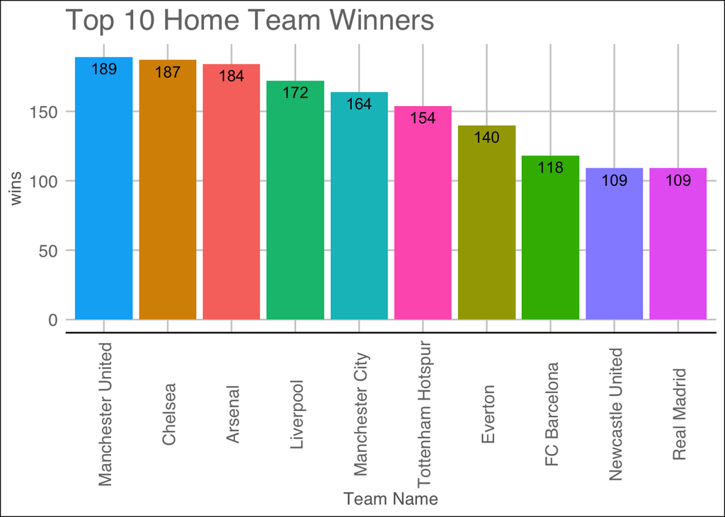

```r
count_homewins =subset(football_df2, winner==1) %>% count(homeTeam )
count_homewins <- count_homewins[with(count_homewins,order(-n)),]
count_homewins <- count_homewins[1:10,]

ggplot(data = count_homewins, aes(x = reorder(homeTeam, -n), y = n, fill = homeTeam)) +
  xlab("Team Name") +
  ylab("wins")+
  labs(title = "Top 10 Home Team Winners ") +
  geom_bar(stat = "identity", position = 'dodge')+
  theme_gdocs()+
  theme(axis.text.x = element_text(angle = 90, vjust = 0.6))+
  geom_text(aes(label = n), vjust = 1.5, colour = "black")+
  theme(legend.position="none")
```

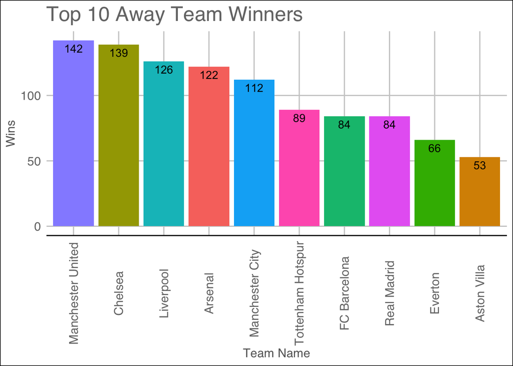

```r
count_awaywins =subset(football_df2, winner==2) %>% count(awayTeam )
count_awaywins <- count_awaywins[with(count_awaywins,order(-n)),]
count_awaywins <- count_awaywins[1:10,]

ggplot(data = count_awaywins, aes(x = reorder(awayTeam, -n), y = n, fill = awayTeam)) +
  xlab("Team Name") +
  ylab("Wins")+
  labs(title = "Top 10 Away Team Winners ") +
  geom_bar(stat = "identity", position = 'dodge')+
  theme_gdocs()+
  theme(axis.text.x = element_text(angle = 90, vjust = 0.5))+
  geom_text(aes(label = n), vjust = 1.5, colour = "black")+
  theme(legend.position="none")
```

**Observations:**

- Manchester United and Chelsea are consistent in the home and away win categories. They both secured top 2 spots.
- Newcastle United is performing well and winning on home grounds, but they are not in picture when it comes to top 10 winning teams on away grounds.
- Aston Villa team is winning matches on away grounds than that of top 10 on home grounds.

**2) Home Win / Draw / Away Win**

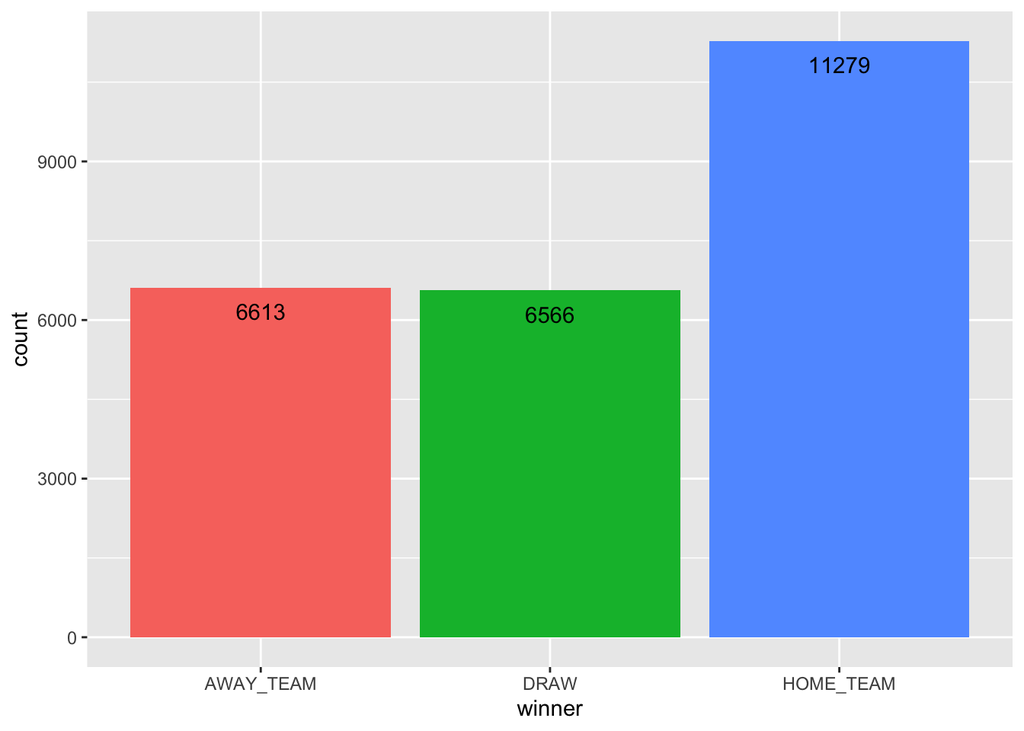

```r
ggplot(football_df, aes(x=winner, fill=as.factor(winner) )) +
  geom_bar( ) +
  scale_fill_hue(c("red", "green", "blue")) +
  geom_text( stat='count', aes(label=..count..), vjust= 2, position = position_dodge(.9) ) +
  theme(legend.position="topright")
```

**Observations:**

- A win of the home-based team has always been the most likely event.
- A win of the visiting team (away team) is the second most likely outcome.
- A draw has been the least likely outcome, although the difference with the count of wins for away_team is nominal.
3. Top 3 home winning teams: matches draw, won and lost

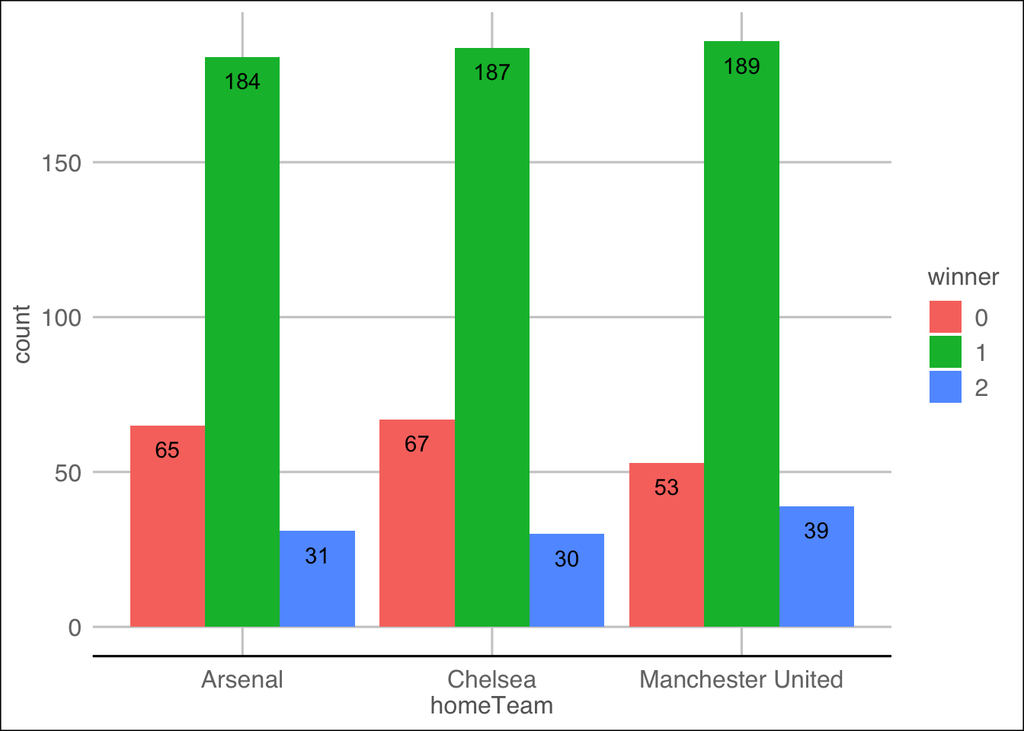

```r
count_homewins_top3 <- count_homewins[1:3,]
count_homewins_top3 <- count_homewins_top3[, c('homeTeam')]
three_team_df <- football_df2[, c('homeTeam', 'winner')] %>%
  filter(grepl('Manchester United|Arsenal|Chelsea', homeTeam))%>%
  group_by(homeTeam)

ggplot(three_team_df, aes(homeTeam)) +
  geom_bar(aes(fill = winner), position="dodge")+
  theme_gdocs()+
  theme(axis.text.x = element_text(angle = 0, vjust = 0.5))+
  geom_text( stat='count', aes(fill = winner, label=..count..), vjust= 2, position = position_dodge(.9) )
```

**Observations** * For all the top 3 winning teams, 66% matches have been won on home ground.

##### Split, Organize and Skim the Data

Split the dataset into train (70%) and test (30%).

```r
intrain <- createDataPartition(y = football_df2$winner,
                               p = 0.7,
                               list = FALSE)

application_train <- football_df2[intrain,]
application_test <- football_df2[-intrain,]
application_test <- application_test %>%
  select(-winner)
```

Below is the train data:

```r
kable(head(application_train,10),format="html",table.attr="style='width:30%;'") %>%
  kableExtra::kable_styling() %>%
  kable_classic(full_width = F,font_size=14)
```

| Odds.homeWin | Odds.draw | Odds.awayWin | hTHome | hTAway | fTHome | fTAway | homeTeam | awayTeam | winner | homePerformancerating | awayPerformancerating |
| --- | --- | --- | --- | --- | --- | --- | --- | --- | --- | --- | --- |
| 2.09 | 3.20 | 3.59 | 0 | 0 | 1 | 0 | Fluminense | Santos | 1 | 0.72 | 0.73 |
| 2.77 | 3.25 | 2.47 | 2 | 0 | 2 | 0 | Santos | São Paulo | 1 | 0.73 | 0.75 |
| 2.61 | 3.08 | 2.78 | 1 | 0 | 2 | 0 | Santos | Fluminense | 1 | 0.73 | 0.72 |
| 2.40 | 3.18 | 3.00 | 0 | 1 | 1 | 1 | Cardiff City | Barnsley | 0 | 0.71 | 0.68 |
| 2.39 | 3.24 | 2.97 | 1 | 1 | 2 | 1 | Blackburn Rovers | Swansea City | 1 | 0.71 | 0.71 |
| 2.34 | 3.17 | 3.10 | 2 | 2 | 3 | 2 | Stoke City | Reading | 1 | 0.70 | 0.71 |
| 2.14 | 3.32 | 3.36 | 1 | 0 | 3 | 0 | Luton Town | Peterborough United | 1 | 0.69 | 0.65 |
| 2.11 | 3.28 | 3.50 | 1 | 1 | 1 | 1 | Bristol City | Blackpool | 0 | 0.70 | 0.65 |
| 2.22 | 3.28 | 3.22 | 1 | 4 | 1 | 4 | Preston North End | Hull City | 2 | 0.70 | 0.67 |
| 1.79 | 3.47 | 4.58 | 0 | 1 | 0 | 1 | Sheffield United | Birmingham City | 2 | 0.73 | 0.70 |

Below is the test data:

```r
kable(head(application_test,10),format="html",table.attr="style='width:30%;'") %>%
  kableExtra::kable_styling() %>%
  kable_classic(full_width = F,font_size=14)
```

| Odds.homeWin | Odds.draw | Odds.awayWin | hTHome | hTAway | fTHome | fTAway | homeTeam | awayTeam | homePerformancerating | awayPerformancerating |
| --- | --- | --- | --- | --- | --- | --- | --- | --- | --- | --- |
| 1.80 | 3.51 | 4.34 | 0 | 0 | 0 | 0 | São Paulo | Fluminense | 0.75 | 0.72 |
| 2.63 | 3.01 | 2.77 | 0 | 1 | 2 | 1 | Fluminense | São Paulo | 0.72 | 0.75 |
| 2.33 | 3.25 | 3.06 | 1 | 1 | 1 | 1 | Queens Park Rangers | Millwall | 0.69 | 0.70 |
| 2.55 | 3.18 | 2.85 | 0 | 1 | 2 | 1 | Peterborough United | Derby County | 0.65 | 0.70 |
| 2.36 | 3.21 | 3.00 | 1 | 1 | 2 | 1 | Reading | Preston North End | 0.71 | 0.70 |
| 3.34 | 3.27 | 2.14 | 0 | 2 | 2 | 2 | Peterborough United | Cardiff City | 0.65 | 0.71 |
| 2.49 | 3.18 | 2.81 | 0 | 2 | 1 | 2 | Nottingham Forest | Blackburn Rovers | 0.71 | 0.71 |
| 2.29 | 3.18 | 3.12 | 1 | 3 | 2 | 3 | Middlesbrough | Queens Park Rangers | 0.70 | 0.69 |
| 1.99 | 3.37 | 3.66 | 0 | 1 | 0 | 1 | Hull City | Derby County | 0.67 | 0.70 |
| 2.36 | 3.19 | 3.09 | 0 | 2 | 2 | 2 | Queens Park Rangers | Barnsley | 0.69 | 0.68 |

Organize the data:

```r
x_train_tbl <- application_train %>%
  select(-winner)
y_train_tbl <- application_train %>%
  select(winner)

x_test_tbl <- application_test
```

Use skim for data inspection:

```r
x_train_tbl_skim = partition(skim(x_train_tbl))
names(x_train_tbl_skim)
```

```
## [1] "character" "numeric"
```

Character Data:

```r
kable(x_train_tbl_skim$character,format="html",table.attr="style='width:30%;'") %>%
  kableExtra::kable_styling() %>%
  kable_classic(full_width = F,font_size=14)
```

| skim_variable | n_missing | complete_rate | min | max | empty | n_unique | whitespace |
| --- | --- | --- | --- | --- | --- | --- | --- |
| homeTeam | 0 | 1 | 2 | 24 | 0 | 112 | 0 |
| awayTeam | 0 | 1 | 2 | 24 | 0 | 113 | 0 |

Numeric Data:

```r
kable(x_train_tbl_skim$numeric,format="html",table.attr="style='width:30%;'") %>%
  kableExtra::kable_styling() %>%
  kable_classic(full_width = F,font_size=14)
```

| skim_variable | n_missing | complete_rate | mean | sd | p0 | p25 | p50 | p75 | p100 | hist |
| --- | --- | --- | --- | --- | --- | --- | --- | --- | --- | --- |
| Odds.homeWin | 0 | 1 | 2.5936266 | 1.7016691 | 1.03 | 1.60 | 2.10 | 2.775 | 20.00 | ▇▁▁▁▁ |
| Odds.draw | 0 | 1 | 3.7438355 | 1.0627053 | 2.30 | 3.20 | 3.40 | 3.900 | 16.00 | ▇▁▁▁▁ |
| Odds.awayWin | 0 | 1 | 4.3283528 | 3.4329589 | 1.10 | 2.40 | 3.20 | 4.900 | 42.00 | ▇▁▁▁▁ |
| hTHome | 0 | 1 | 0.7015615 | 0.8574124 | 0.00 | 0.00 | 0.00 | 1.000 | 5.00 | ▇▁▁▁▁ |
| hTAway | 0 | 1 | 0.5643281 | 0.7920544 | 0.00 | 0.00 | 0.00 | 1.000 | 6.00 | ▇▁▁▁▁ |
| fTHome | 0 | 1 | 1.5792830 | 1.3235962 | 0.00 | 1.00 | 1.00 | 2.000 | 8.00 | ▇▆▁▁▁ |
| fTAway | 0 | 1 | 1.1565868 | 1.1553839 | 0.00 | 0.00 | 1.00 | 2.000 | 6.00 | ▇▂▁▁▁ |
| homePerformancerating | 0 | 1 | 0.7775764 | 0.0495929 | 0.65 | 0.76 | 0.78 | 0.820 | 0.85 | ▂▃▇▆▇ |
| awayPerformancerating | 0 | 1 | 0.7782868 | 0.0494095 | 0.65 | 0.76 | 0.78 | 0.820 | 0.85 | ▂▃▇▆▇ |

##### Data Wrangling for ML

```r
string_2_factor_names <- x_train_tbl_skim$character$skim_variable
string_2_factor_names
```

```
## [1] "homeTeam" "awayTeam"
```

```r
unique_numeric_values_tbl <- x_train_tbl %>%
  select(x_train_tbl_skim$numeric$skim_variable) %>%
  map_df(~ unique(.) %>% length()) %>%
  gather() %>%
  arrange(value) %>%
  mutate(key = as_factor(key))
unique_numeric_values_tbl
```

```
## # A tibble: 9 × 2
##   key                   value
##   <fct>                 <int>
## 1 hTHome                    6
## 2 hTAway                    7
## 3 fTAway                    7
## 4 fTHome                    9
## 5 homePerformancerating    21
## 6 awayPerformancerating    21
## 7 Odds.draw               187
## 8 Odds.homeWin            283
## 9 Odds.awayWin            335
```

```r
factor_limit <- 15
num_2_factor_names <- unique_numeric_values_tbl %>%
  filter(value < factor_limit) %>%
  arrange(desc(value)) %>%
  pull(key) %>% # pull out a single variable as a vector
  as.character()
num_2_factor_names
```

```
## [1] "fTHome" "hTAway" "fTAway" "hTHome"
```

##### Recipes for ML Data Transformation

```r
rec_obj <- recipe(~ ., data = x_train_tbl) %>%
  step_string2factor(all_of(string_2_factor_names)) %>%
  step_num2factor(all_of(num_2_factor_names),
                  levels=str_c(0:330),
                  transform = function(x) x + 1) %>%
  step_impute_mean(all_numeric()) %>% # missing values in numeric columns
  step_impute_mode(all_nominal()) %>% # missing values in factor columns
  prep(training = x_train_tbl)

rec_obj
```

```
## Recipe
##
## Inputs:
##
##       role #variables
##  predictor         11
##
## Training data contained 4547 data points and no missing data.
##
## Operations:
##
## Factor variables from homeTeam, awayTeam [trained]
## Factor variables from fTHome, hTAway, fTAway, hTHome [trained]
## Mean Imputation for Odds.homeWin, Odds.draw, Odds.awayWin, homePerf... [trained]
## Mode Imputation for hTHome, hTAway, fTHome, fTAway, homeTeam, awayTeam [trained]
```

Start baking:

```r
x_train_processed_tbl <- bake(rec_obj, x_train_tbl)
x_test_processed_tbl <- bake(rec_obj, x_test_tbl)
```

View the train before and after baking:

```r
x_train_tbl %>% # original data before baking
  select(1:11) %>%
  glimpse()
```

```
## Rows: 4,547
## Columns: 11
## $ Odds.homeWin          <dbl> 2.09, 2.77, 2.61, 2.40, 2.39, 2.34, 2.14, 2.11, …
## $ Odds.draw             <dbl> 3.20, 3.25, 3.08, 3.18, 3.24, 3.17, 3.32, 3.28, …
## $ Odds.awayWin          <dbl> 3.59, 2.47, 2.78, 3.00, 2.97, 3.10, 3.36, 3.50, …
## $ hTHome                <int> 0, 2, 1, 0, 1, 2, 1, 1, 1, 0, 1, 0, 0, 1, 0, 0, …
## $ hTAway                <int> 0, 0, 0, 1, 1, 2, 0, 1, 4, 1, 1, 2, 1, 1, 3, 0, …
## $ fTHome                <int> 1, 2, 2, 1, 2, 3, 3, 1, 1, 0, 1, 0, 1, 2, 0, 0, …
## $ fTAway                <int> 0, 0, 0, 1, 1, 2, 0, 1, 4, 1, 1, 2, 1, 1, 3, 0, …
## $ homeTeam              <chr> "Fluminense", "Santos", "Santos", "Cardiff City"…
## $ awayTeam              <chr> "Santos", "São Paulo", "Fluminense", "Barnsley",…
## $ homePerformancerating <dbl> 0.72, 0.73, 0.73, 0.71, 0.71, 0.70, 0.69, 0.70, …
## $ awayPerformancerating <dbl> 0.73, 0.75, 0.72, 0.68, 0.71, 0.71, 0.65, 0.65, …
```

```r
x_train_processed_tbl %>% # processed data after baking
  select(1:11) %>%
  glimpse()
```

```
## Rows: 4,547
## Columns: 11
## $ Odds.homeWin          <dbl> 2.09, 2.77, 2.61, 2.40, 2.39, 2.34, 2.14, 2.11, …
## $ Odds.draw             <dbl> 3.20, 3.25, 3.08, 3.18, 3.24, 3.17, 3.32, 3.28, …
## $ Odds.awayWin          <dbl> 3.59, 2.47, 2.78, 3.00, 2.97, 3.10, 3.36, 3.50, …
## $ hTHome                <fct> 0, 2, 1, 0, 1, 2, 1, 1, 1, 0, 1, 0, 0, 1, 0, 0, …
## $ hTAway                <fct> 0, 0, 0, 1, 1, 2, 0, 1, 4, 1, 1, 2, 1, 1, 3, 0, …
## $ fTHome                <fct> 1, 2, 2, 1, 2, 3, 3, 1, 1, 0, 1, 0, 1, 2, 0, 0, …
## $ fTAway                <fct> 0, 0, 0, 1, 1, 2, 0, 1, 4, 1, 1, 2, 1, 1, 3, 0, …
## $ homeTeam              <fct> Fluminense, Santos, Santos, Cardiff City, Blackb…
## $ awayTeam              <fct> Santos, São Paulo, Fluminense, Barnsley, Swansea…
## $ homePerformancerating <dbl> 0.72, 0.73, 0.73, 0.71, 0.71, 0.70, 0.69, 0.70, …
## $ awayPerformancerating <dbl> 0.73, 0.75, 0.72, 0.68, 0.71, 0.71, 0.65, 0.65, …
```

Transform the outcome variable (y):

```r
rec_obj_for_y <- recipe(~ ., data = y_train_tbl) %>%
  prep(stringsAsFactors = FALSE)
y_train_processed_tbl <- bake(rec_obj_for_y, y_train_tbl)
```

##### Use H2o

We will use h2o

```r
library(h2o)
h2o.init(nthreads = -1)
```

[output not shown]

```r
h2o.clusterInfo()
```

```
## R is connected to the H2O cluster:
##     H2O cluster uptime:         5 seconds 533 milliseconds
##     H2O cluster timezone:       America/New_York
##     H2O data parsing timezone:  UTC
##     H2O cluster version:        3.32.1.3
##     H2O cluster version age:    6 months and 18 days !!!
##     H2O cluster name:           H2O_started_from_R_mitaliwarty_cql537
##     H2O cluster total nodes:    1
##     H2O cluster total memory:   3.54 GB
##     H2O cluster total cores:    8
##     H2O cluster allowed cores:  8
##     H2O cluster healthy:        TRUE
##     H2O Connection ip:          localhost
##     H2O Connection port:        54321
##     H2O Connection proxy:       NA
##     H2O Internal Security:      FALSE
##     H2O API Extensions:         Amazon S3, XGBoost, Algos, AutoML, Core V3, TargetEncoder, Core V4
##     R Version:                  R version 4.1.1 (2021-08-10)
```

##### Push data into h2o

```r
data_h2o <- as.h2o(
  bind_cols(y_train_processed_tbl, x_train_processed_tbl),
  destination_frame= "train.hex")
new_data_h2o <- as.h2o(
  x_test_processed_tbl,
  destination_frame= "test.hex" #destination_frame is optional
)
data_h2o_no_destination <- as.h2o(
  bind_cols(y_train_processed_tbl, x_train_processed_tbl)
)
```

Splitting the training data into 3 subsets: * one for training: to fit a model * one for validation: to scoring the parameters * one for testing: to find the performance

```r
splits <- h2o.splitFrame(data = data_h2o,
                         ratios = c(0.7, 0.15), # 70/15/15 split
                         seed = 1234)
train_h2o <- splits[[1]] # from training data
valid_h2o <- splits[[2]] # from training data
test_h2o <- splits[[3]]  # from training data
```

##### Deep Learning Model 1

```r
y <- "winner" # column name for outcome
x <- colnames(select(football_df2,-c('winner','homeTeam','awayTeam','fTHome','fTAway')))

m1 <- h2o.deeplearning(
  model_id = "dl_model_first",
  x = x,
  y = y,
  training_frame = train_h2o,
  validation_frame = valid_h2o,
  epochs = 100
)
```

##### Deep Learning Model 2 with some serious tuning

```r
m2 <- h2o.deeplearning(
  model_id="dl_model_tuned",
  x = x,
  y = y,
  training_frame = train_h2o,
  validation_frame = valid_h2o,
  overwrite_with_best_model = F, ## Return the final model after 100 epochs,
  ## even if not the best
  hidden = c(150,150,150), ## more hidden layers -> more complex interactions
  epochs = 100,
  score_validation_samples = 10000, ## downsample validation set for faster scoring
  score_duty_cycle = 0.025, ## don't score more than 2.5% of the wall time
  adaptive_rate = F, ## manually tuned learning rate
  rate = 0.01,
  rate_annealing = 2e-6,
  momentum_start = 0.2, ## manually tuned momentum
  momentum_stable = 0.4,
  momentum_ramp = 1e7,
  l1 = 1e-5, ## add some L1/L2 regularization
  l2 = 1e-5,
  max_w2 = 10 ## helps stability for Rectifier
)
```

##### Hyper-parameter tuning w/grid search

We also tried different values for a parameter, so used hyper-parameter tuning with grid search. Here, we constructed a grid to store and try each combination defined in the hyper_params list.

```r
hyper_params <- list(
  hidden = list( c(50,50,50), c(100,100) ),
  input_dropout_ratio = c(0, 0.05),
  rate = c(0.01, 0.02),
  rate_annealing = c(1e-8, 1e-7, 1e-6)
)

grid <- h2o.grid(
  algorithm="deeplearning",
  grid_id="dl_grid",
  x = x,
  y = y,
  training_frame = train_h2o,
  validation_frame = valid_h2o,
  epochs = 100,
  stopping_metric = "misclassification",
  stopping_tolerance = 1e-2,
  stopping_rounds = 2,
  score_validation_samples = 10000, ## downsample validation set for faster scoring
  score_duty_cycle = 0.025, ## don't score more than 2.5% of the wall time
  adaptive_rate = F, #manually tuned learning rate
  momentum_start = 0.5, #manually tuned momentum
  momentum_stable = 0.9,
  momentum_ramp = 1e7,
  l1 = 1e-5,
  l2 = 1e-5,
  activation = c("Rectifier"),
  max_w2 = 10, #can help improve stability for Rectifier
  hyper_params = hyper_params
)
```

##### AutoML in h2o

```r
automl_models_h2o <- h2o.automl(
x = x,
y = y,
training_frame = train_h2o,
validation_frame = valid_h2o,
leaderboard_frame = test_h2o,
max_runtime_secs = 900
)
```

```
##
## 16:23:16.425: User specified a validation frame with cross-validation still enabled. Please note that the models will still be validated using cross-validation only, the validation frame will be used to provide purely informative validation metrics on the trained models.
```

##### ML Result Summary and Discussion

Below is the result summary from the basic deep learning model m1:

```r
summary(m1)
```

```
## Model Details:
## ==============
##
## H2OMultinomialModel: deeplearning
## Model Key:  dl_model_first
## Status of Neuron Layers: predicting winner, 3-class classification, multinomial distribution, CrossEntropy loss, 45,003 weights/biases, 536.7 KB, 319,700 training samples, mini-batch size 1
##   layer units      type dropout       l1       l2 mean_rate rate_rms momentum
## 1     1    20     Input  0.00 %       NA       NA        NA       NA       NA
## 2     2   200 Rectifier  0.00 % 0.000000 0.000000  0.174823 0.374991 0.000000
## 3     3   200 Rectifier  0.00 % 0.000000 0.000000  0.055033 0.111016 0.000000
## 4     4     3   Softmax      NA 0.000000 0.000000  0.006172 0.004239 0.000000
##   mean_weight weight_rms mean_bias bias_rms
## 1          NA         NA        NA       NA
## 2   -0.018381   0.099484  0.212697 0.082511
## 3   -0.022459   0.075328  0.859551 0.073743
## 4   -0.035142   0.321536 -0.046403 0.016096
##
## H2OMultinomialMetrics: deeplearning
## ** Reported on training data. **
## ** Metrics reported on full training frame **
##
## Training Set Metrics:
## =====================
##
## Extract training frame with `h2o.getFrame("RTMP_sid_b5ca_5")`
## MSE: (Extract with `h2o.mse`) 0.275684
## RMSE: (Extract with `h2o.rmse`) 0.5250562
## Logloss: (Extract with `h2o.logloss`) 0.8062261
## Mean Per-Class Error: 0.391529
## AUC: (Extract with `h2o.auc`) NaN
## AUCPR: (Extract with `h2o.aucpr`) NaN
## Confusion Matrix: Extract with `h2o.confusionMatrix(<model>,train = TRUE)`)
## =========================================================================
## Confusion Matrix: Row labels: Actual class; Column labels: Predicted class
##           0    1   2  Error            Rate
## 0       468  238 105 0.4229 =     343 / 811
## 1       347 1092  49 0.2661 =   396 / 1,488
## 2       334  102 462 0.4855 =     436 / 898
## Totals 1149 1432 616 0.3675 = 1,175 / 3,197
##
```

[output cut: 89 more lines]

```
## 6               hTHome.1            0.830980          0.830980   0.060483
## 7               hTAway.1            0.825939          0.825939   0.060116
## 8               hTAway.5            0.788421          0.788421   0.057386
## 9               hTAway.4            0.786882          0.786882   0.057274
## 10              hTAway.2            0.785428          0.785428   0.057168
## 11              hTHome.4            0.783689          0.783689   0.057041
## 12              hTHome.5            0.757201          0.757201   0.055113
## 13              hTHome.2            0.755517          0.755517   0.054991
## 14             Odds.draw            0.676848          0.676848   0.049265
## 15          Odds.awayWin            0.652350          0.652350   0.047482
## 16          Odds.homeWin            0.605083          0.605083   0.044041
## 17 awayPerformancerating            0.463624          0.463624   0.033745
## 18 homePerformancerating            0.424475          0.424475   0.030896
## 19    hTAway.missing(NA)            0.000000          0.000000   0.000000
## 20    hTHome.missing(NA)            0.000000          0.000000   0.000000
```

Below is the result summary from the slightly enhanced deep learning model m2, with some tuning:

```r
summary(m2)
```

```
## Model Details:
## ==============
##
## H2OMultinomialModel: deeplearning
## Model Key:  dl_model_tuned
## Status of Neuron Layers: predicting winner, 3-class classification, multinomial distribution, CrossEntropy loss, 48,903 weights/biases, 390.8 KB, 319,700 training samples, mini-batch size 1
##   layer units      type dropout       l1       l2 mean_rate rate_rms momentum
## 1     1    20     Input  0.00 %       NA       NA        NA       NA       NA
## 2     2   150 Rectifier  0.00 % 0.000010 0.000010  0.006100 0.000000 0.206394
## 3     3   150 Rectifier  0.00 % 0.000010 0.000010  0.006100 0.000000 0.206394
## 4     4   150 Rectifier  0.00 % 0.000010 0.000010  0.006100 0.000000 0.206394
## 5     5     3   Softmax      NA 0.000010 0.000010  0.006100 0.000000 0.206394
##   mean_weight weight_rms mean_bias bias_rms
## 1          NA         NA        NA       NA
## 2   -0.020432   0.225250  0.319223 0.097518
## 3   -0.025668   0.103837  0.913216 0.068762
## 4   -0.042776   0.110188  0.910942 0.061135
## 5   -0.011904   0.249127 -0.006017 0.441930
##
## H2OMultinomialMetrics: deeplearning
## ** Reported on training data. **
## ** Metrics reported on full training frame **
##
## Training Set Metrics:
## =====================
##
## Extract training frame with `h2o.getFrame("RTMP_sid_b5ca_5")`
## MSE: (Extract with `h2o.mse`) 0.2434128
## RMSE: (Extract with `h2o.rmse`) 0.4933688
## Logloss: (Extract with `h2o.logloss`) 0.7294967
## Mean Per-Class Error: 0.3649821
## AUC: (Extract with `h2o.auc`) NaN
## AUCPR: (Extract with `h2o.aucpr`) NaN
## Confusion Matrix: Extract with `h2o.confusionMatrix(<model>,train = TRUE)`)
## =========================================================================
## Confusion Matrix: Row labels: Actual class; Column labels: Predicted class
##          0    1   2  Error            Rate
## 0      367  311 133 0.5475 =     444 / 811
## 1      160 1250  78 0.1599 =   238 / 1,488
## 2      198  150 550 0.3875 =     348 / 898
```

[output cut: 91 more lines]

```
## 6              Odds.draw            0.854366          0.854366   0.066779
## 7               hTAway.1            0.819962          0.819962   0.064090
## 8               hTHome.1            0.773029          0.773029   0.060422
## 9               hTHome.3            0.710132          0.710132   0.055505
## 10              hTAway.3            0.706166          0.706166   0.055195
## 11              hTAway.2            0.672655          0.672655   0.052576
## 12          Odds.awayWin            0.654160          0.654160   0.051131
## 13              hTHome.2            0.632916          0.632916   0.049470
## 14              hTAway.4            0.528808          0.528808   0.041333
## 15              hTHome.4            0.456443          0.456443   0.035677
## 16              hTAway.5            0.404223          0.404223   0.031595
## 17              hTHome.5            0.390973          0.390973   0.030559
## 18              hTAway.6            0.368197          0.368197   0.028779
## 19    hTAway.missing(NA)            0.000000          0.000000   0.000000
## 20    hTHome.missing(NA)            0.000000          0.000000   0.000000
```

Results from hyper-param tuning.

```r
grid <- h2o.getGrid("dl_grid", sort_by="logloss", decreasing=FALSE)
dl_grid_summary_table <- grid@summary_table
dl_grid_summary_table
```

```
## Hyper-Parameter Search Summary: ordered by increasing logloss
##         hidden input_dropout_ratio rate rate_annealing        model_ids
## 1   [100, 100]                 0.0 0.01         1.0E-7 dl_grid_model_10
## 2   [100, 100]                0.05 0.01         1.0E-8  dl_grid_model_4
## 3 [50, 50, 50]                 0.0 0.01         1.0E-8  dl_grid_model_1
## 4   [100, 100]                0.05 0.02         1.0E-8  dl_grid_model_8
## 5 [50, 50, 50]                0.05 0.01         1.0E-7 dl_grid_model_11
##              logloss
## 1 0.7931522439644659
## 2 0.7940167464246534
## 3 0.8037062014728219
## 4 0.8060949288197355
## 5 0.8071931302234734
##
## ---
##          hidden input_dropout_ratio rate rate_annealing        model_ids
## 19   [100, 100]                0.05 0.02         1.0E-6 dl_grid_model_24
## 20   [100, 100]                0.05 0.02         1.0E-7 dl_grid_model_16
## 21 [50, 50, 50]                 0.0 0.02         1.0E-8  dl_grid_model_5
## 22 [50, 50, 50]                 0.0 0.02         1.0E-7 dl_grid_model_13
## 23 [50, 50, 50]                 0.0 0.01         1.0E-7  dl_grid_model_9
## 24   [100, 100]                 0.0 0.02         1.0E-7 dl_grid_model_14
##               logloss
## 19 0.9881220271278013
## 20 0.9943855927890376
## 21 1.0242478188330972
## 22 1.0874069033195675
## 23 1.1295000487818079
## 24  1.137622236799107
```

To find best model in the grid

```r
dl_grid_best_model <- h2o.getModel(dl_grid_summary_table$model_ids[1])
summary(dl_grid_best_model)
```

```
## Model Details:
## ==============
##
## H2OMultinomialModel: deeplearning
## Model Key:  dl_grid_model_10
## Status of Neuron Layers: predicting winner, 3-class classification, multinomial distribution, CrossEntropy loss, 12,503 weights/biases, 103.9 KB, 319,700 training samples, mini-batch size 1
##   layer units      type dropout       l1       l2 mean_rate rate_rms momentum
## 1     1    20     Input  0.00 %       NA       NA        NA       NA       NA
## 2     2   100 Rectifier  0.00 % 0.000010 0.000010  0.009690 0.000000 0.512788
## 3     3   100 Rectifier  0.00 % 0.000010 0.000010  0.009690 0.000000 0.512788
## 4     4     3   Softmax      NA 0.000010 0.000010  0.009690 0.000000 0.512788
##   mean_weight weight_rms mean_bias bias_rms
## 1          NA         NA        NA       NA
## 2   -0.009261   0.155254  0.417773 0.058464
## 3   -0.030400   0.105641  0.914953 0.027931
## 4    0.007267   0.238261 -0.046709 0.173274
##
## H2OMultinomialMetrics: deeplearning
## ** Reported on training data. **
## ** Metrics reported on full training frame **
##
## Training Set Metrics:
## =====================
##
## Extract training frame with `h2o.getFrame("RTMP_sid_b5ca_5")`
## MSE: (Extract with `h2o.mse`) 0.2837396
## RMSE: (Extract with `h2o.rmse`) 0.5326722
## Logloss: (Extract with `h2o.logloss`) 0.7810208
## Mean Per-Class Error: 0.4125583
## AUC: (Extract with `h2o.auc`) NaN
## AUCPR: (Extract with `h2o.aucpr`) NaN
## Confusion Matrix: Extract with `h2o.confusionMatrix(<model>,train = TRUE)`)
## =========================================================================
## Confusion Matrix: Row labels: Actual class; Column labels: Predicted class
##          0    1   2  Error            Rate
## 0      178  403 230 0.7805 =     633 / 811
## 1       99 1280 109 0.1398 =   208 / 1,488
## 2       83  202 613 0.3174 =     285 / 898
## Totals 360 1885 952 0.3522 = 1,126 / 3,197
##
```

[output cut: 84 more lines]

```
## 6               hTHome.2            0.690673          0.690673   0.056114
## 7               hTAway.4            0.690277          0.690277   0.056082
## 8               hTAway.1            0.688903          0.688903   0.055970
## 9               hTAway.2            0.679969          0.679969   0.055244
## 10          Odds.homeWin            0.637545          0.637545   0.051797
## 11             Odds.draw            0.614314          0.614314   0.049910
## 12              hTAway.5            0.608072          0.608072   0.049403
## 13          Odds.awayWin            0.597057          0.597057   0.048508
## 14 homePerformancerating            0.588920          0.588920   0.047847
## 15 awayPerformancerating            0.582844          0.582844   0.047353
## 16              hTHome.4            0.565297          0.565297   0.045928
## 17              hTHome.5            0.547976          0.547976   0.044520
## 18              hTAway.6            0.524035          0.524035   0.042575
## 19    hTAway.missing(NA)            0.000000          0.000000   0.000000
## 20    hTHome.missing(NA)            0.000000          0.000000   0.000000
```

To find parameters used in the best model

```r
dl_grid_best_model_params <- dl_grid_best_model@allparameters
dl_grid_best_model_params
```

```
## $model_id
## [1] "dl_grid_model_10"
##
## $training_frame
## [1] "RTMP_sid_b5ca_5"
##
## $validation_frame
## [1] "RTMP_sid_b5ca_7"
##
## $nfolds
## [1] 0
##
## $keep_cross_validation_models
## [1] TRUE
##
## $keep_cross_validation_predictions
## [1] FALSE
##
## $keep_cross_validation_fold_assignment
## [1] FALSE
##
## $ignore_const_cols
## [1] TRUE
##
## $score_each_iteration
## [1] FALSE
##
## $balance_classes
## [1] FALSE
##
## $max_after_balance_size
## [1] 5
##
## $max_confusion_matrix_size
## [1] 20
##
## $overwrite_with_best_model
## [1] TRUE
##
## $use_all_factor_levels
```

[output cut: 180 more lines]

```
## [1] 0.9
##
## $elastic_averaging_regularization
## [1] 0.001
##
## $auc_type
## [1] "AUTO"
##
## $x
## [1] "hTAway"                "hTHome"                "Odds.homeWin"
## [4] "Odds.draw"             "Odds.awayWin"          "homePerformancerating"
## [7] "awayPerformancerating"
##
## $y
## [1] "winner"
```

Below is the result summary from AutoML model.

```r
automl_leaderboard <- automl_models_h2o@leaderboard
automl_leaderboard
```

```
##                                              model_id mean_per_class_error
## 1 DeepLearning_grid__1_AutoML_20211208_162316_model_6            0.3843737
## 2 DeepLearning_grid__3_AutoML_20211208_162316_model_6            0.3851586
## 3 DeepLearning_grid__3_AutoML_20211208_162316_model_1            0.3868197
## 4      XGBoost_grid__1_AutoML_20211208_162316_model_6            0.3913877
## 5 DeepLearning_grid__2_AutoML_20211208_162316_model_1            0.3938415
## 6     XGBoost_grid__1_AutoML_20211208_162316_model_10            0.3954601
##     logloss      rmse       mse auc aucpr
## 1 0.8027024 0.5275817 0.2783424 NaN   NaN
## 2 0.8264039 0.5468119 0.2990033 NaN   NaN
## 3 0.8401652 0.5334946 0.2846164 NaN   NaN
## 4 0.7815439 0.5289093 0.2797450 NaN   NaN
## 5 0.7781892 0.5296231 0.2805006 NaN   NaN
## 6 0.7851636 0.5308467 0.2817982 NaN   NaN
##
## [59 rows x 7 columns]
```

```r
automl_leader <- automl_models_h2o@leader
```

Confusion matrix from Auto ML:

```r
performance_h2o <- h2o.performance(automl_leader, newdata = test_h2o)
performance_h2o %>%
h2o.confusionMatrix()
```

```
## Confusion Matrix: Row labels: Actual class; Column labels: Predicted class
##          0   1   2  Error        Rate
## 0       58  61  52 0.6608 = 113 / 171
## 1       48 232  34 0.2611 =  82 / 314
## 2       24  22 153 0.2312 =  46 / 199
## Totals 130 315 239 0.3523 = 241 / 684
```

Close the h2o:

```r
h2o.shutdown(prompt = F)
```